# The impact of multiple features on trip duration feature

## by Rahaf Aljehani

## Investigation Overview

> Throughout my investigation, I focused on the Trip Duration feature. My main goal was to find which of the other features has an impact on my chosen feature of interest. Moreover, I analyzed multiple features relationship regarding my feature of interest to have a better understanding of the whole features and how they affect my chosen feature of interest.

## Dataset Overview

> I selected Ford GoBike System dataset for analysis, it includes information about individual rides made in a bike-sharing system covering the greater San Francisco Bay area. This data contains 183412 individual rides with 16 features, these features include duration variables such as:duration in sec, start time and end time, also include users information such as:user type and gender.

## Distribution of trips duration

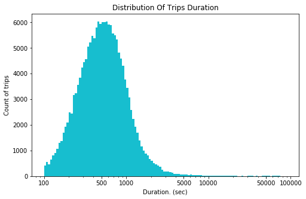

## Distribution of trips taken in days of the week

The number of trips increases on Thursday, and the number of trips decreases on Saturday and Sunday.

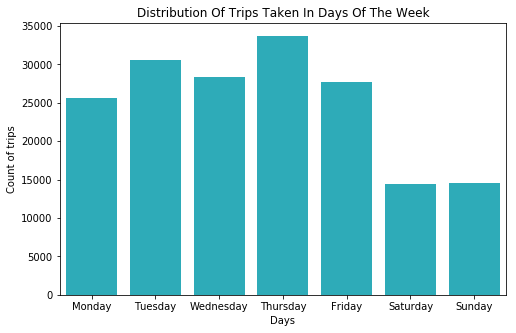

## The impact of week days trip on trip duration

on Saturday and Sunday, the duration of the trips is longer than the rest of the week.

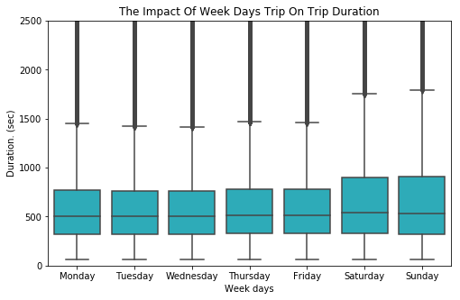

## The impact of user age on trip duration

The users who spend more trip duration are between the ages of 18 and 40 years.

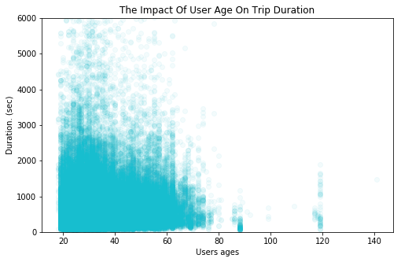

## Trip duration and days of week by user type

- In general, customer users have a longer trip duration throughout the week than subscriber users.
- On Saturday and Sunday, the duration of the trips was longer than the rest of the days of the week for both the subscribers and customers users.

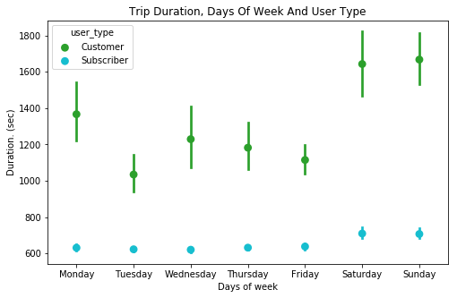

## Trip duration and days of week by user gender

- In general, females users have a longer trip duration throughout the week than males users.
- On Saturday and Sunday, the duration of the trips was longer than the rest of the days of the week for both the females and males users .

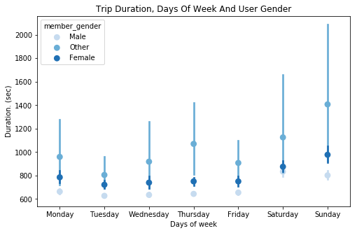